# Clase 6 - Mapas

Domenech Burin, Laia

25 junio, 2022

```r
knitr::opts_chunk$set(echo=TRUE, message=FALSE, warning=FALSE )
```

## Mirando al espacio

Los mapas son una unidad visual que puede reconocer prácticamente la totalidad de la población de una región determinada. La visualización de mapas y el análisis espacial solía estar reservado para especialistas, debido a la complejidad y costo de este tipo de procesos. Pero durante las dos últimas décadas la tecnología digital cambió el panorama. Una dramática caída en el costo asociado a adquirir y procesar información geográfica (pensemos en satélites y computadoras multiplicándose y bajando de precio) dio paso al mapa digital como herramienta universal.

Hoy en día, hacer mapas resulta algo muy fácil. Existen cada vez más repositorios con información georreferenciada de acceso publico -datasets que incluyen información precisa sobre su ubicación geográfica. Al mismo tiempo, maduran y se hacen más fáciles de usar las herramientas para análisis y visualización espacial.

En R contamos con varios paquete de funciones que permiten manipular información espacial con facilidad. A continuación vamos a aprender a combinarlos con las herramientas que ya hemos aprendido, para hacer análisis geográfico y crear nuestros propios mapas.

### Geometrías

Los archivos de datos geográficos relacionados con fenómenos sociales (datos de cosas que somos y hacemos los humanos, como composición de población, trazado de rutas, ubicación de hospitales, etc) suelen ser de tipo vectorial. Los datos vectoriales expresan la posición y extensión de cosas mediante geometrías, que pueden ser de puntos, de líneas, o de polígonos. En la jerga de los sistemas de información geográfica, se les llama “capas” (*layers*) a los archivos que contienen estas geometrías, y en ese sentido se hablar de combinar capas para crear mapas.

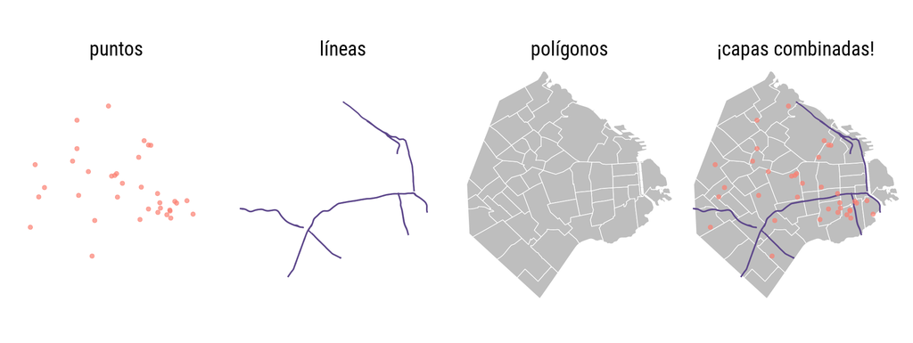

- Un archivo geográfico con geometría de **puntos** se utiliza para marcar **posiciones**: por ejemplo, puntos que señalen la ubicación de hospitales.
- La geometría de **líneas** permite mostrar **recorridos**: como por ejemplo la extensión de ríos, de autopistas o de calles.
- Los **polígonos** se usan cuando hay que representar **superficies**: el territorio de barrios, provincias o países; el terreno ocupado por parques y plazas, la extensión de parcelas, los límites de áreas especiales como un coto de caza, etc.

### Los datos georreferenciados

Los datos georeferenciados reciben su nombre justamente porque están vinculados a locaciones en el mundo físico. Estaciones de subte, hogares, reservas ecológicas, cualquier lugar que exista. Si bien hoy en día es más fácil que nunca trabajar con este tipo de datos, tienen algunas complicaciones.

La principal de ellas está vinculada con la forma esférica irregular de la Tierra. No es un círculo perfecto, sino que está “achatada” en los polos, dificultando la matemática necesaria para comparar posiciones y medir distancias. Esta forma hace que sea imposible de representar a la exactitud en un plano de dos dimensiones. El proceso a través del cual desplegamos la tierra en dos para dibujarla en un mapa plano es la **proyección**.

Las proyecciones cartográficas son instrucciones para traducir a un plano la disposición de puntos ubicados en la esfera terrestre. Toman como base los CRS: un sistema de números que definen ubicaciones sobre la superficie de la Tierra. El más conocido es el que usa latitud y longitud, para definir posiciones en los ejes norte-sur y este-oeste.

Inevitablemente, las proyecciones van a introducir distorsiones porque uan superficie curva no puede ser proyectada con exactitud en una superficie plana. Más específicamente, la proyección puede preservar ángulos o áreas pero no ambas. Existen muchísimas proyecciones distintas, cada una pensada para minimizar alguno de los tipos de distorsión, o para encontrar una solución de compromiso que los balancee.

La proyección más famosa y utilizada es la Mercator, que fue desarrollada en el siglo 16 para la navegación marítima. Esta proyección tiene como ventaja que no distorsiona las direcciones, por lo que permite fijar un rumbo de navegación consultando el mapa. Su principal problema es que produce una distorsión notable en las áreas cercanas a los polos: Groenlandia aparenta el mismo tamaño que toda África, cuando en realidad tiene sólo un quinceavo de su superficie.

Sin embargo, Google la eligió para sus mapas en línea, y por razones de compatibilidad otros proveedores de mapas digitales la adoptaron también. Así, y para entendible irritación de especialistas en geografía, Mercator se convirtió en el estándar de facto para aplicaciones geográficas y mapas en la web.

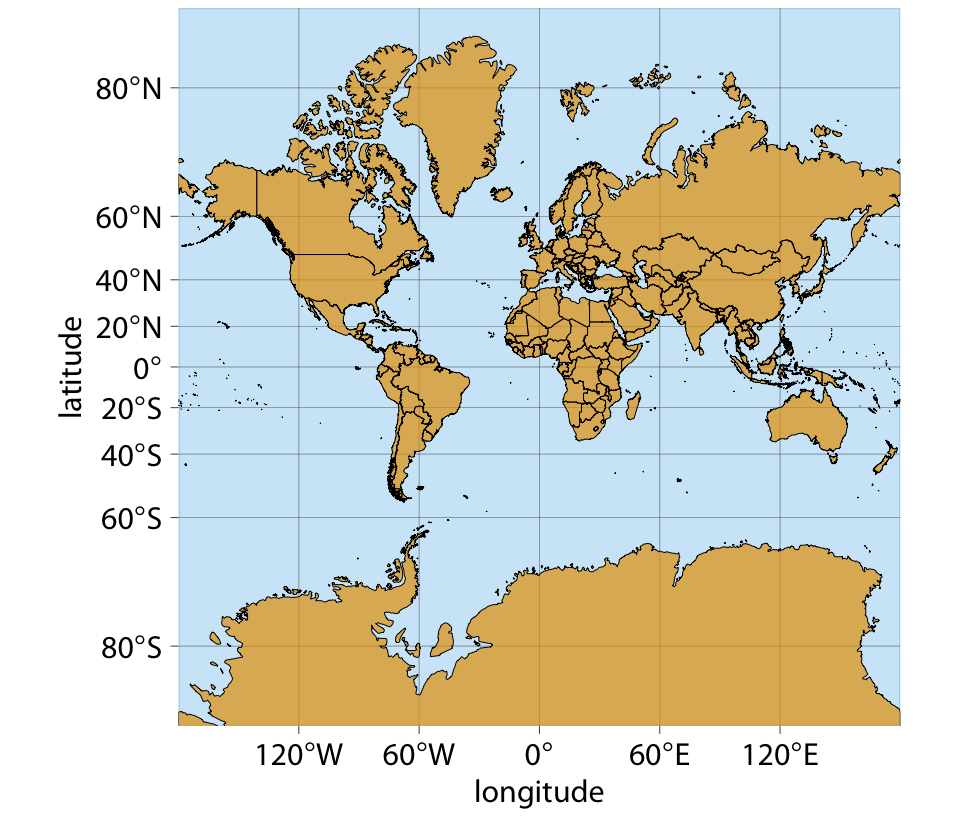

En la práctica, si trabajamos en forma frecuente con archivos georreferenciados vamos a sufrir tarde o temprano de problemas de coordenadas o proyección. El más común de ellos: tener una fuentes de datos geográficos que no podemos comparar con otras, porque desconocemos el sistema de coordenadas que se usó para crearla; es decir, no podemos saber a que posición sobre el planeta corresponde cada observación en los datos.

### Importando la data

Otro problema asociado a trabajar con datos geográficos es el de los formatos de archivo. El formato más común es el denominado “shapefile”, inventado por la empresa ESRI (los creadores del software ArcGIS). Es un formato incómodo porque guarda la información en varios archivos distintos, que suelen ser combinados en un archivo .zip para su distribución. Un inconveniente aún mayor es que los nombres de las variables en un shapefile deben tener 10 caracteres o menos, lo que facilita el uso de abreviaturas ininteligibles. A pesar de éstos y otros detrimentos, el formato es tan común que se ha vuelto sinónimo de archivo con información geográfica, y resiste a pesar de los esfuerzos por reemplazarlo con alternativas más modernas. Una de ellas es “GeoJSON”, un estándar abierto que corrige los dos inconvenientes mencionados antes. Para nuestros ejercicios usaremos datos geográficos en esta último formato.

Vamos a continuar trabajando con `ggplot2`, pero además vamos a incluir el paquete `sf` que sirve para trabajar específicamente con datos georeferenciados.

```r
library(tidyverse)
library(ggplot2)
library(sf)
```

```r
geo <- read_sf("./data/provincias.geojson")
```

La data contiene información básica de cada provincia. Sin embargo, van a ver tiene una columna particular, cuyo formato no habíamos visto aún: `geometry`. Esta columna tiene la información de una serie de puntos que trazan un **polígono**. En otras palabras, contiene la forma de cada provincia Por esto esta variable será fundamental para realizar mapas en R, es el insumo básico de donde el programa saca la información para trazarlos.

Vamos a filtrar las provincias de interés:

```r
geo <- geo %>% filter(nomprov %in% c("NEUQUEN", "RIO NEGRO", "CHUBUT", "SANTA CRUZ", "TIERRA DEL FUEGO") )
```

A partir de esto, graficar un mapa es tan simple como usar dos líneas de ggplot con la geometría `geom_sf`.

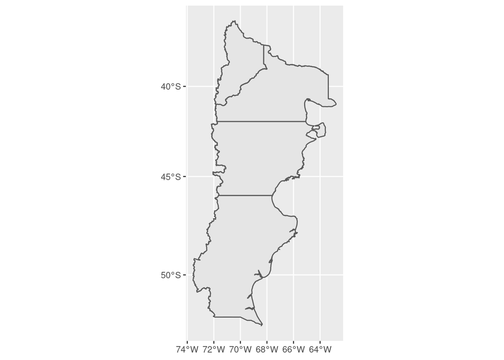

```r
ggplot(geo)+
        geom_sf()
```

### Información en mapas

Con frecuencia vemos información presentada en mapas. Un ejemplo de ellos es el [mapa del delito](https://mapa.seguridadciudad.gob.ar/) de CABA, otro es el [mapa de accesibilidad](https://acceso.shinyapps.io/mapa/) de factor~data. Detengámonos un segundo a ver, ¿cuáles son las propiedades estéticas utilizadas para mostrar la información?

La forma más común de mostrar información geográfica es a través de **mapas coropléticos**, donde se colorean regiones individualmente de acuerdo a la dimensión de la información que se quiere mostrar. Para hacerlo, nada más hay que asignarle al atributo `fill`la dimensión que queremos plasmar.

Vamos a agregarle capas de información a nuestro mapa. Por ejemplo, supongamos que queremos ver en el mapa qué provincias tuvieron una mayor cantidad de homicidios dolosos en el año 2020. Para esto podemos usar la base de datos con la que estuvimos trabajando las últimas clases. Vamos a filtrarla e importar los casos que nos interesan.

```r
df <- readxl::read_xlsx("data/Integrado_HD_base_usuaria_2017-2020.xlsx")

#Formato
patagonia <- df %>% filter(provincia %in% c("NEUQUEN", "RIO NEGRO", "CHUBUT", "SANTA CRUZ", "TIERRA DEL FUEGO"))
```

Luego, joineamos las dos bases. Una cosa **muy importante** es que siempre hay que poner la base con las geometrías a la izquierda, de lo contrario la columna `geometry` pierde el formato.

```r
#Join
geo <- geo %>% left_join(patagonia, by=c("nomprov"="provincia"))
```

Ahora podemos hacer lo que ya sabemos: filtramos el año, luego agrupamos y contamos los casos por `Id_hecho`.

```r
tb1 <- geo%>%
        filter(anio == 2020) %>%
        group_by(nomprov)%>%
        summarise(n=n_distinct(Id_hecho, na.rm = FALSE))
```

Como estamos trabajando el gráfico con `ggplot`, podemos pasarle el atributo estético `n` al parámetro `fill` para que los polígonos se pinten según la frecuencia de casos.

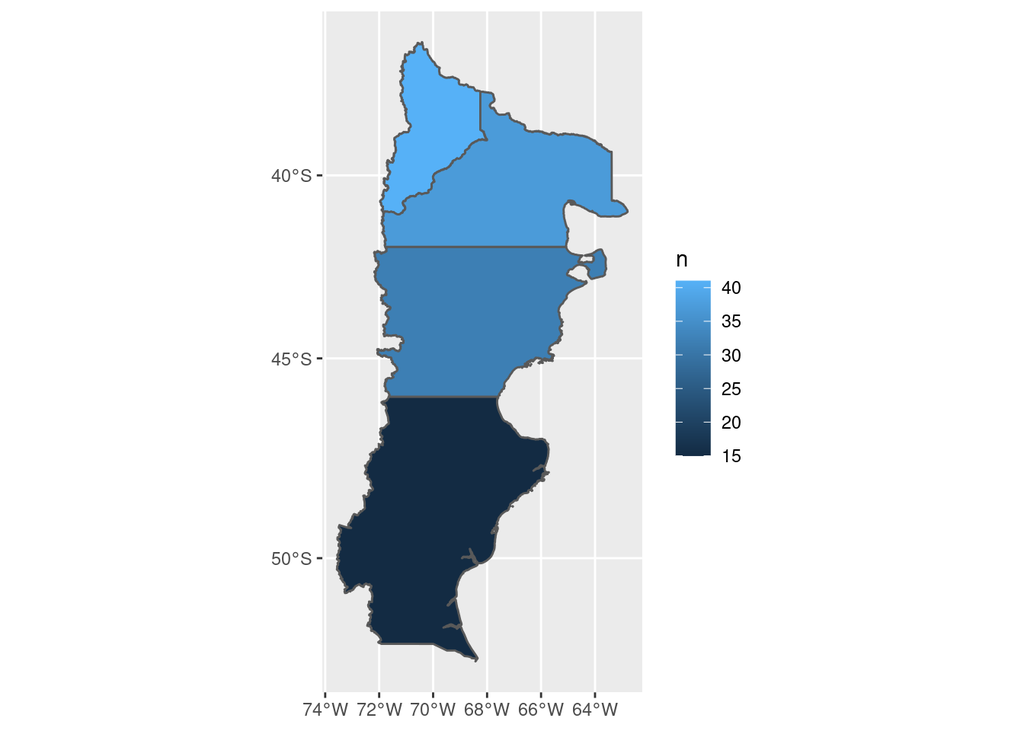

```r
ggplot(tb1, aes(fill=n))+
        geom_sf()
```

Acá ya vemos información. Pero vamos a emprolijar un poco el gráfico borrando líneas grises que dibujan cada polígono.Esto lo hacemos asignándole al parámetro `color = NA`:

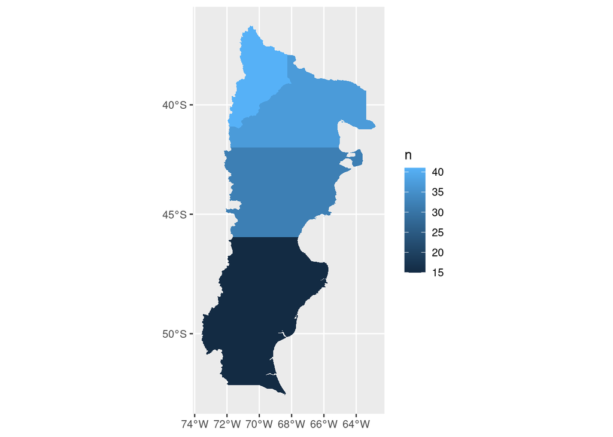

```r
ggplot(tb1)+
        geom_sf(aes(fill = n), color = NA)
```

En este mapa, Neuquén destaca como la provincia con mayor cantidad de homicidios en 2020. Sin embargo, algo que no hemos mencionado aún es la importancia de “normalizar” las variables antes de mostrarlas en un mapa. En general, los lugares más grandes van a contener dentro “más” de cualquier variable que los lugares pequeños (sean personas, comercios o accidentes). Lo que sería más útil aquí es presentar la relación entre homicidios y la cantidad de habitantes.

Por eso vamos a incorporar un dataframe que nos de adicional: las proyecciones poblacionales por provincia.

```r
proyecciones <- read_csv("./data/proyecciones_prov.csv")

head(proyecciones)
```

```
## # A tibble: 6 × 3
##   Provincia  anio   proy
##   <chr>     <dbl>  <dbl>
## 1 CHUBUT     2017 587956
## 2 CHUBUT     2018 598380
## 3 CHUBUT     2019 608729
## 4 CHUBUT     2020 618994
## 5 LA PAMPA   2017 349299
## 6 LA PAMPA   2018 352378
```

```r
geo <- geo %>%
        left_join(proyecciones, by = c("nomprov" = "Provincia", "anio")) #Joineo por provincia y año del registro/proyección
```

Ahora sí, vamos a agrupar por año, departamento y tamaño de la población.

```r
tb2 <- geo%>%
        filter(anio == 2020)%>%
        group_by(nomprov, proy)%>%
        summarise(n_casos=n_distinct(Id_hecho, na.rm = TRUE))
```

Y lo vamos a graficar.

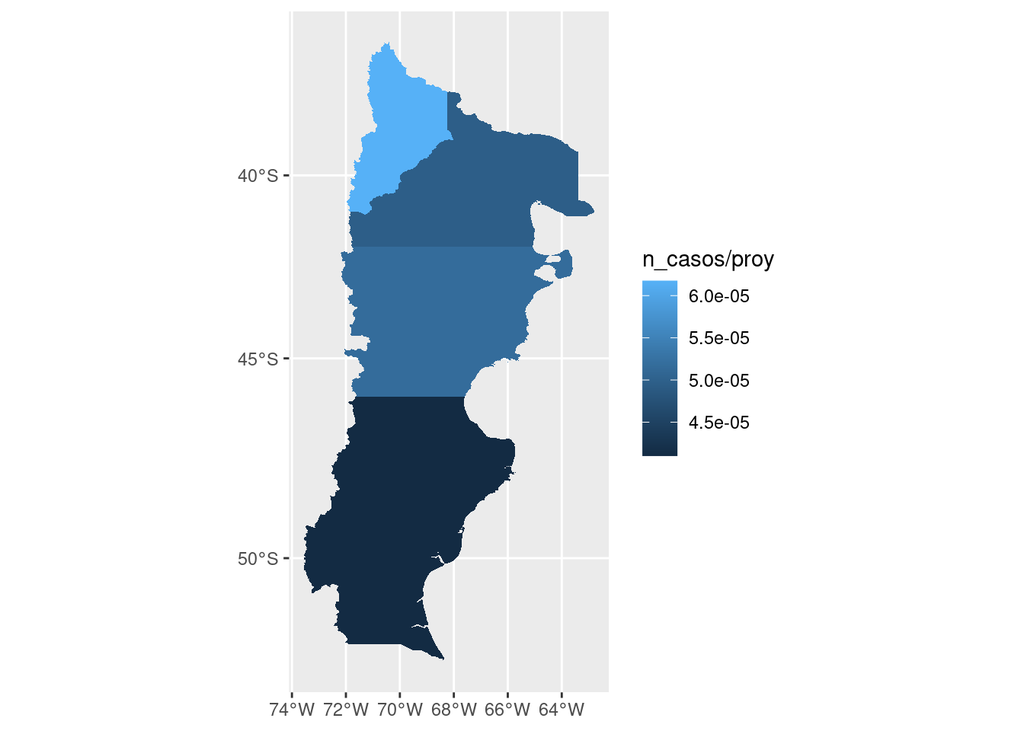

```r
ggplot(tb2)+
        geom_sf(aes(fill = n_casos/proy), color = NA)
```

Este último gráfico representa de forma mucho mas precisa la distribución homicidios dolosos por habitante en cada provincia. Podemos ver que si bien Neuquén sigue teniendo la mayor cantidad de casos, Río Negro tiene una relación de homicidios/habitantes un poco más baja de la que veíamos en el gráfico anterior.

Tenemos una mejora más por realizar: elegir una escala de color que haga más legible el gráfico, ayudando al ojo a diferenciar las áreas donde la densidad es particularmente alta o baja. Apelamos a [“viridis”](https://cran.r-project.org/web/packages/viridis/vignettes/intro-to-viridis.html), una escala diseñada para ser fácil de interpretar… y lucir bien de paso. Para usar virids, agregamos `scale_fill_viridis_d()` cuando se muestra una variable categórica, y `scale_fill_viridis_c()`cuando se trata de una variable continua, el cual es nuestro caso.

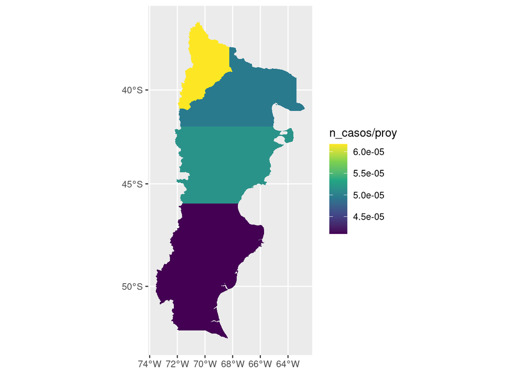

```r
library(viridis)

ggplot(tb2)+
        geom_sf(aes(fill = n_casos/proy), color = NA)+
        scale_fill_viridis_c()
```

Para cerrar, y dejar nuestro gráfico bien prolijo, vamos a agregarle título, subtítulo y modificar el nombre de la barra de relleno con `labs`. También vamos a sacar la notación científica de los HD/cantidad de habitantes poniendo el parámetro `labels = scales::label_comma()`. Con esto estamos modificando los labels de la barra, y llamamos a la función `label_comma()` del paquete `scales` para poner labels con coma. Finalmente, vamos a sacar las referencias de coordenadas de los ejes x e y con el atributo `axis.text.x=element_blank()` y `axis.ticks.x=element_blank()` para cada eje.

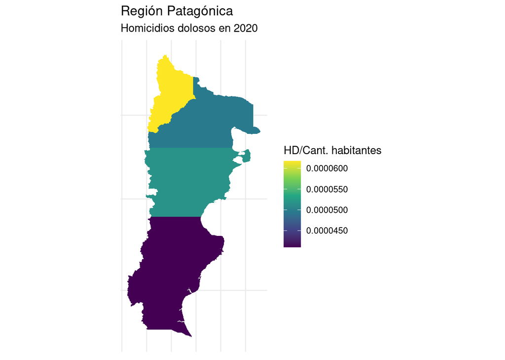

```r
ggplot(tb2)+
        geom_sf(aes(fill = n_casos/proy), color = NA)+
        scale_fill_viridis_c(labels = scales::label_comma())+
        labs(title = "Región Patagónica",
             subtitle = "Homicidios dolosos en 2020",
             fill = "HD/Cant. habitantes")+
        theme_minimal()+
        theme(axis.text.x=element_blank(),
                axis.ticks.x=element_blank(),
                axis.text.y=element_blank(),
                axis.ticks.y=element_blank()
                )
```

### Tiempo y espacio

Otra cosa que podemos hacer con la información y herramientas que tenemos es mostrar la evolución temporal de los casos a lo largo de los años en todas las provincias. Como tenemos la columna *anio* podemos utilizarla para agrupar directamente los casos por ella, pero sino podríamos usar `lubridate` para hacer una columna de los años.

```r
tb3 <- geo%>%
        group_by(anio, nomprov, proy)%>%
        summarise(n_casos=n_distinct(Id_hecho, na.rm = TRUE))
```

Para hacer el gráfico tenemos que replicar el código que veníamos haciendo, pero ahí nos falta introducir la variable `anio`. La vamos a meter agregando la capa `facet_grid()` y pasando dentro el atributo `vars(anio)`.

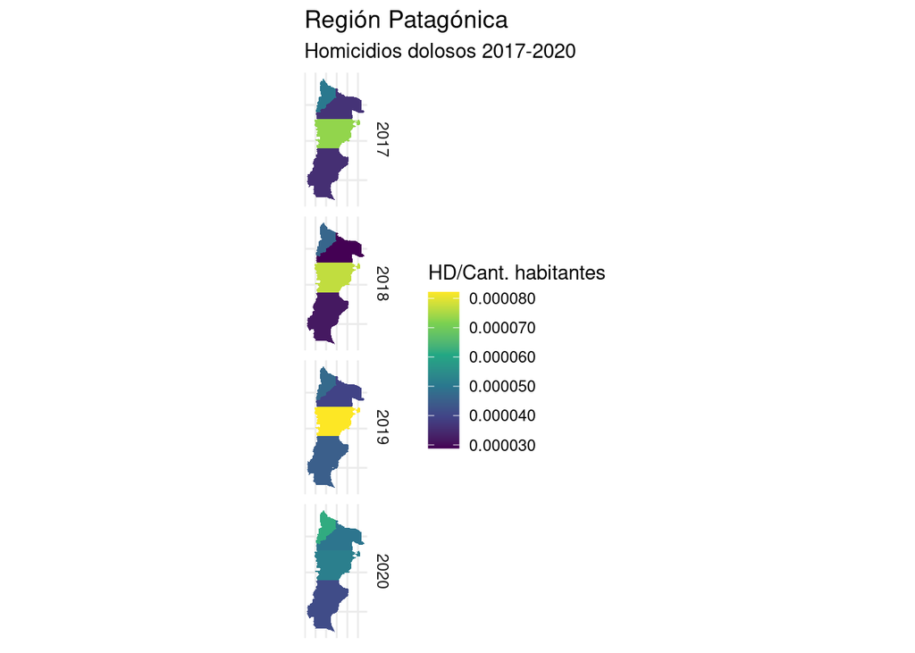

```r
ggplot(tb3)+
        geom_sf(aes(fill = n_casos/proy), color = NA)+
        scale_fill_viridis_c(labels = scales::label_comma())+
        facet_grid(vars(anio))+
        labs(title = "Región Patagónica",
             subtitle = "Homicidios dolosos 2017-2020",
             fill = "HD/Cant. habitantes")+
        theme_minimal()+
        theme(axis.text.x=element_blank(),
                axis.ticks.x=element_blank(),
                axis.text.y=element_blank(),
                axis.ticks.y=element_blank()
                )
```

Acá tenemos un problema. Cada una de las facetas es bastante “larga”, y por default `facet_grid(vars(anio))` pasa la variable de facetado como filas. Esto lo corregimos asignando la variable de año al atributo `cols`, de la siguiente manera: `facet_grid(cols = vars(anio))`.

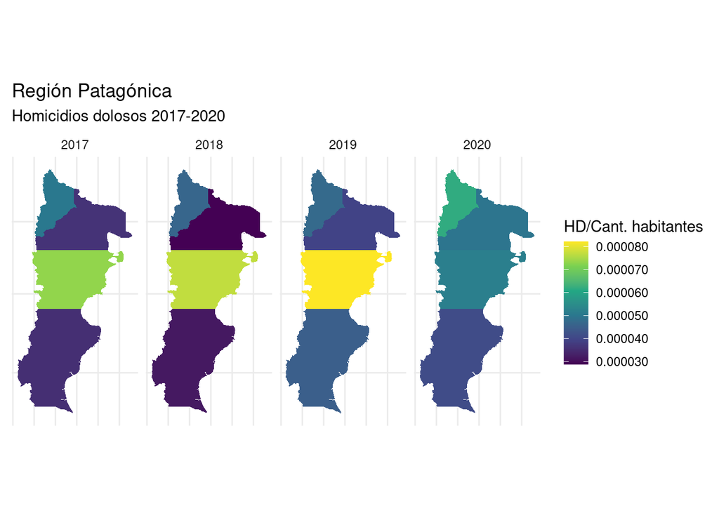

```r
ggplot(tb3)+
        geom_sf(aes(fill = n_casos/proy), color = NA)+
        scale_fill_viridis_c(labels = scales::label_comma())+
        facet_grid(cols = vars(anio))+
        labs(title = "Región Patagónica",
             subtitle = "Homicidios dolosos 2017-2020",
             fill = "HD/Cant. habitantes")+
        theme_minimal()+
        theme(axis.text.x=element_blank(),
                axis.ticks.x=element_blank(),
                axis.text.y=element_blank(),
                axis.ticks.y=element_blank()
                )
```

Como paso final, vamos a exportar la tabla donde generamos los datos del gráfico 2 usando la función `st_write`:

```r
#st_write(tb2, "./data/homicidios_prov_patagonia.geojson")
```

Ahora, pasemos a la parte práctica.